# Lab03 - Monte Carlo Methods in R

Jarad Niemi

2018-01-22

To follow along, use the lab03 code.

## Programming in R

R is made up primarily of

- objects
- functions

We discussed many R objects in lab 01, but there are many more.

### Functions

Functions are written to be performed on objects. The function below simply adds 1 to whatever the argument is.

```r
add1 <- function(a) {
  return(a+1)
}

add1(2)
```

```
## [1] 3
```

```r
add1(a = 3)
```

```
## [1] 4
```

The following function adds the two arguments.

```r
add <- function(a, b) {
  return(a+b)
}

add(1,1)
```

```
## [1] 2
```

```r
add(a = 2, b = 3)
```

```
## [1] 5
```

Many functions in R are vectorized meaning they can take vector arguments and return a sensible value. As written, our functions are vectorized, e.g.

```r
add1(a = 1:2)
```

```
## [1] 2 3
```

```r
add(a = 1:2, b = 3:4)
```

```
## [1] 4 6
```

This is usually helpful, but it is not always clear what the results should be. For example, what do you think the result is if you run

```r
add(a = 1:4, b = 1:2)
```

### Arguments

Arguments to functions can be provided by order or by name or both. You can also specify arguments using a partial name.

```r
f <- function(first, second) {
  return(first/2 + second)
}

f(1,2)
```

```
## [1] 2.5
```

```r
f(1, second = 2)
```

```
## [1] 2.5
```

```r
f(first = 1, second = 2)
```

```
## [1] 2.5
```

```r
f(second = 2, 1) # I thought this was going to be an error
```

```
## [1] 2.5
```

```r
f(f = 1, s = 2)
```

```
## [1] 2.5
```

My suggestion is that you always use argument full names when writing your code. Due to RStudio’s tab-autocomplete, typing in the full name should not slow you down.

Many functions have default arguments. You can specify default arguments in the functions you write by using the `=` sign in the function definition.

```r
add <- function(a, b = 1) {
  return(a+b)
}

add(a = 1)
```

```
## [1] 2
```

```r
add(a = 1:2)
```

```
## [1] 2 3
```

```r
add(a = 2:3, b =  2)
```

```
## [1] 4 5
```

```r
add(a = 3:4, b = -1)
```

```
## [1] 2 3
```

For example, the `norm` functions have default arguments that correspond to a standard normal, i.e. `mean=0` and `sd=1`.

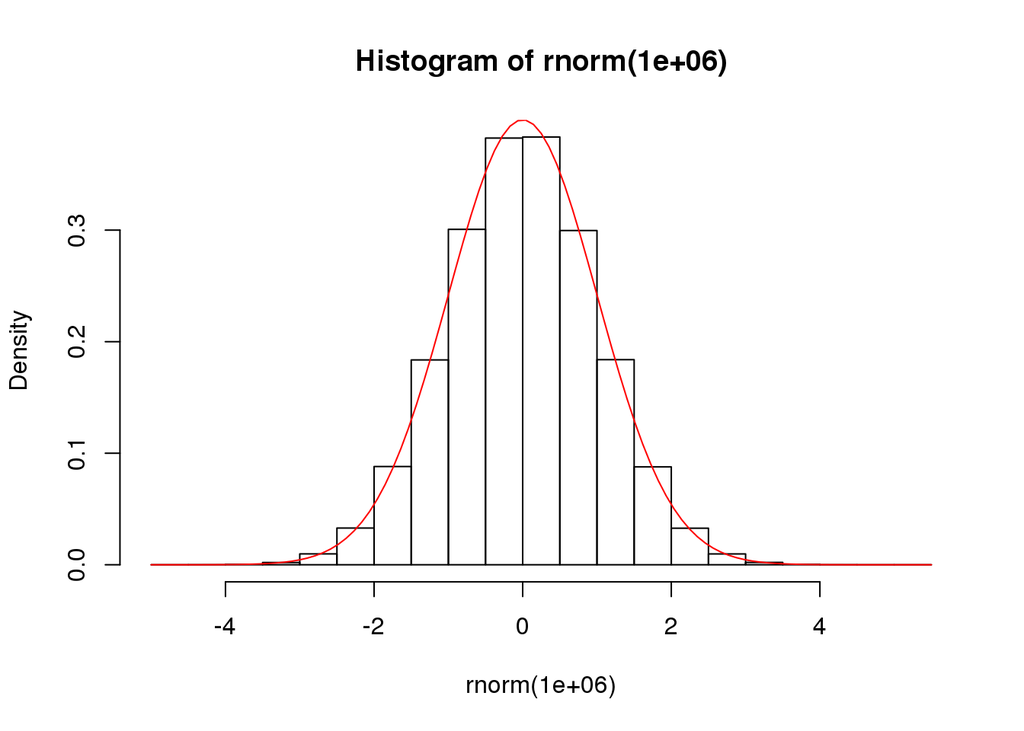

```r
hist(rnorm(1e6), probability = TRUE)
curve(dnorm(x), add = TRUE, col = 'red')
```

#### Function activity

Create a function with arguments named `first` and `second` and have the function subtract the second argument from the first. Provide a default for `first` that is the vector `1:2` and for `second` that is the value `1`.

```r
sub <- function(first = 1:2, second = 1) {
  return(first - second)
}
```

### Generic Functions

R has generic functions, i.e. functions where the type of object passed as the first argument to the function determine which version of the function to actually run. The `print()` function is a generic function

```r
?print
```

Notice in the help file it says “It is a generic function”.

To determine exactly what function will be executed when using the a generic function, you need to determine the `class` of the object.

Here is an example

```r
n <- 10
x <- rnorm(n)
y <- rnorm(n, x)
m <- lm(y~x) # a linear regression
summary(m)
```

```
##
## Call:
## lm(formula = y ~ x)
##
## Residuals:
##      Min       1Q   Median       3Q      Max
## -1.46277 -0.40714 -0.04316  0.33003  1.83098
##
## Coefficients:
##             Estimate Std. Error t value Pr(>|t|)
## (Intercept) -0.08598    0.30246  -0.284   0.7834
## x            1.10365    0.25640   4.304   0.0026 **
## ---
## Signif. codes:  0 '***' 0.001 '**' 0.01 '*' 0.05 '.' 0.1 ' ' 1
##
## Residual standard error: 0.9106 on 8 degrees of freedom
## Multiple R-squared:  0.6984, Adjusted R-squared:  0.6607
## F-statistic: 18.53 on 1 and 8 DF,  p-value: 0.0026
```

Here the generic function `summary()` checked the class of `m`.

```r
class(m)
```

```
## [1] "lm"
```

and found that the class is `lm` and uses the appropriate summary function, i.e. `summary.lm()`.

There are other helpful functions for `lm` objects, e.g.

```r
summary(m)
```

```
##
## Call:
## lm(formula = y ~ x)
##
## Residuals:
##      Min       1Q   Median       3Q      Max
## -1.46277 -0.40714 -0.04316  0.33003  1.83098
##
## Coefficients:
##             Estimate Std. Error t value Pr(>|t|)
## (Intercept) -0.08598    0.30246  -0.284   0.7834
## x            1.10365    0.25640   4.304   0.0026 **
## ---
## Signif. codes:  0 '***' 0.001 '**' 0.01 '*' 0.05 '.' 0.1 ' ' 1
##
## Residual standard error: 0.9106 on 8 degrees of freedom
## Multiple R-squared:  0.6984, Adjusted R-squared:  0.6607
## F-statistic: 18.53 on 1 and 8 DF,  p-value: 0.0026
```

```r
anova(m)
```

```
## Analysis of Variance Table
##
## Response: y
##           Df  Sum Sq Mean Sq F value Pr(>F)
## x          1 15.3635 15.3635  18.528 0.0026 **
## Residuals  8  6.6338  0.8292
## ---
## Signif. codes:  0 '***' 0.001 '**' 0.01 '*' 0.05 '.' 0.1 ' ' 1
```

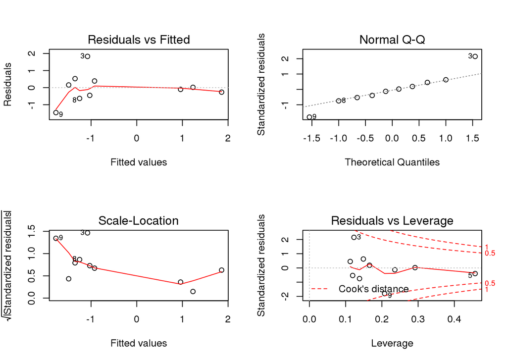

```r
opar <- par(mfrow=c(2,2)); plot(m); par(opar)
```

### Scope

The objects available to an R function are defined by the scope of the function. But if the object is not available within the function, then the function will look to the environment containing that function to see if the object is there.

```r
a <- 1
f <- function() {
  return(a)
}
f()
```

```
## [1] 1
```

If we modify the object within the function, that version of the object is only available within the function.

```r
f <- function() {
  a <- 2
  return(a)
}
f()
```

```
## [1] 2
```

```r
a
```

```
## [1] 1
```

Unless we use a special assignment operator `<<-`

```r
f <- function() {
  a <<- a + 1
  return(a)
}
a
```

```
## [1] 1
```

```r
f()
```

```
## [1] 2
```

```r
a
```

```
## [1] 2
```

So **be careful** when constructing functions to deal appropriately with the scope of the objects you are using!

### Loops

Basic programming often consists of using loops and conditionals. R has `for` and `while` loops as well as `if`-`else` statements.

Here is a basic `for` loop:

```r
for (i in 1:3) {
  print(i)
}
```

```
## [1] 1
## [1] 2
## [1] 3
```

A basic `while` loop:

```r
i <- 0
while (i < 3) {
  i <- i + 1
  print(i)
}
```

```
## [1] 1
## [1] 2
## [1] 3
```

And a basic use of the `if`-`else` statement:

```r
for (i in 1:10) {
  if (i<5) {
    print(-i)
  } else {
    print(i*2)
  }
}
```

```
## [1] -1
## [1] -2
## [1] -3
## [1] -4
## [1] 10
## [1] 12
## [1] 14
## [1] 16
## [1] 18
## [1] 20
```

There is also a useful `ifelse` function, but it is a little confusing. This function takes in a vector logical first argument and two more scalar arguments. For each element in the logical vector, it will return the first scalar argument when the element is true and the second scalar argument when the element is false.

```r
ifelse((1:10) < 5, "Less than 5", "Not less than 5")
```

```
##  [1] "Less than 5"     "Less than 5"     "Less than 5"
##  [4] "Less than 5"     "Not less than 5" "Not less than 5"
##  [7] "Not less than 5" "Not less than 5" "Not less than 5"
## [10] "Not less than 5"
```

#### Loop activity

Create a function that has a single scalar argument named `a`. Use a loop inside the function to calculate the sum of the numbers from 1 to a and return this sum. Test using the sum up to 100 which should be 5050.

```r
f <- function(a) {
  sum <- 0
  for (i in 1:a) {
    sum <- sum + i
  }
  return(sum)
}
f(100)
```

```
## [1] 5050
```

## Monte Carlo Methods in R

With the prevalence of computers, statistics is increasingly utilizing methods based on simulations to answer scientific questions of interest. These methods are called Monte Carlo methods.

### Monte Carlo integration

Monte Carlo methods can be used to answer any integration question. For example, suppose we want to estimate the integral of the function $f(x) = x^2$ evaluated from 0 to 1. We can sample uniform values from 0 to 1, calculate x at each of these values, and take their average.

```r
n <- 1e4
sum <- 0
for (i in 1:n) {
  x <- runif(1)
  sum <- sum + x^2
}
sum/n
```

```
## [1] 0.3360568
```

or, more succinctly (and quicker),

```r
y <- runif(n)^2
mean(y)
```

```
## [1] 0.3371087
```

We did not discuss it, but the [Strong Law of Large Numbers](https://en.wikipedia.org/wiki/Law_of_large_numbers#Strong_law) guarantees that if we take a large enough sample, we will converge in probability to the true integral. We can visualize this by calculating the running mean.

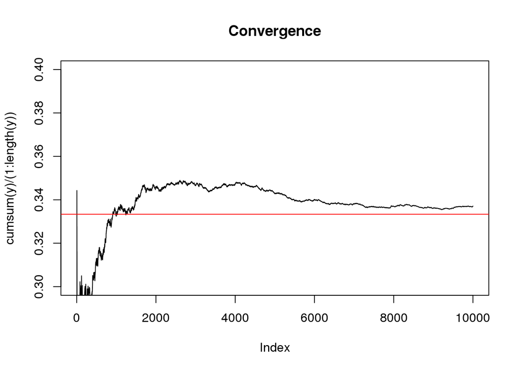

```r
plot( cumsum(y)/(1:length(y)), type='l', main='Convergence', ylim=c(.3,.4))
abline(h=1/3, col='red')
```

We would also like to know, at any number of simulated values, how far away we are likely to be. The [Central Limit Theorem](https://en.wikipedia.org/wiki/Central_limit_theorem) provides a way to evaluate the Monte Carlo error in our estimate. Recall that the CLT says that an average of iid random variables has a normal distribution with mean equal to the expectation and variance equal to the variance of an individual random variate divided by n.

In this case, the random variable is $X^2$ where $X\sim Unif(0,1)$. We can estimate the mean and variance by taking a large number of $X^2$ values and calculating their mean and variance, e.g.

```r
mean(y) # Notice that this is the estimate of the integral that we are trying to find
```

```
## [1] 0.3371087
```

```r
var(y)
```

```
## [1] 0.08915463
```

For any particular number of simulations $n$, a 95% interval for the value of the integral is
$$\overline{Y} \pm 1.96 s/\sqrt{n}$$
where $s$ is the estimated standard deviation (square root of the variance). Based on our samples we have

```r
mean(y) + c(-1,1)*qnorm(0.975)*sd(y)/sqrt(length(y))
```

```
## [1] 0.3312565 0.3429609
```

We can visualize the increasing certainty by calculating this interval for each new simulation we have.

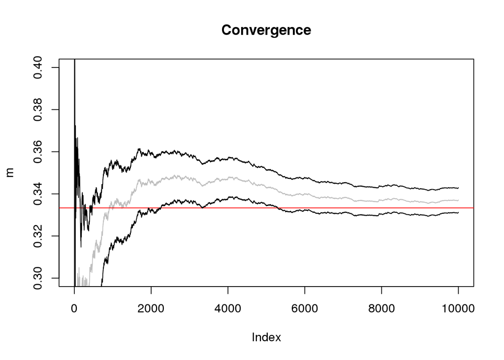

```r
m <- cumsum(y)/(1:length(y))
s <- numeric(n)
for (i in 1:n) {
  s[i] <- qnorm(0.975)*sd(y[1:i])/sqrt(i)
}

plot(m, type='l', col='gray', main='Convergence', ylim=c(.3,.4))
abline(h=1/3, col='red')
lines(m+s)
lines(m-s)
```

#### Integral activity

Estimate the integral
$$\int_{-1}^1 e^{-|x|} dx$$
by Monte Carlo integration and provide a 95% interval. You will need to

1. draw uniform random values from $(-1,1)$,
2. calculate $e^{-|x|}$ for each of these values using the `exp()` and `abs()` functions,
3. calculate the mean and standard deviation of these values, and
4. construct the interval.

```r
n <- 1e5
x <- runif(n, min = -1, max = 1)
y <- exp(-abs(x))
m <- mean(y)
s <- qnorm(.975)*sd(y)/length(y)
m + c(-1,1)*s
```

```
## [1] 0.6337349 0.6337420
```

### Evaluating expectations

Suppose we have a random variable with the probability mass function

| x | 0 | 1 | 2 | 3 |
| --- | --- | --- | --- | --- |
| p(x) | .5 | .25 | .1 | .15 |

Now you are interested in estimating its expectation. If you can simulate from this distribution, then you can just take an average of the simulated values.

To simulate from a discrete random variable with finite support, you can use the `sample()` function.

```r
x <- sample(0:3, size = 1e5, prob = c(.5,.25,.1,.15), replace = TRUE)
```

Now we can calculate the expectation and standard deviation (or variance) of these values which are estimates of the expectation and standard deviation (or variance) of the random variable.

```r
(m <- mean(x))
```

```
## [1] 0.89643
```

```r
(s <- sd(x))
```

```
## [1] 1.088005
```

```r
s^2 # variance
```

```
## [1] 1.183755
```

The CLT can be used to provide bounds. For example a 90% interval is

```r
m + c(-1,1) * qnorm(.95) * s / sqrt( length(x) )
```

```
## [1] 0.8907708 0.9020892
```

#### Expectation activity

Find the expectation for discrete random variable with the following pmf:

| x | 10 | 12 | 21 | 33 |
| --- | --- | --- | --- | --- |
| p(x) | .1 | .2 | .3 | .4 |

Also find a 99% interval for this expectation using the CLT based on a million samples.

```r
x <- sample(c(10,12,21,33), size = 1e6, prob = c(.1,.2,.3,.4), replace = TRUE)
m <- mean(x)
s <- sd(x)
m + c(-1,1) * qnorm(.995) * s / sqrt( length(x) )
```

```
## [1] 22.88425 22.93099
```

### Estimating probabilities

We can also use simulations to estimate probabilities. Suppose we have a random variable $X\sim Unif(0,1)$ and a random variable $Y\sim N(0,1)$ and we are interested in calculating the probability that $X$ is larger than $Y$. This is not an easy calculation to do by hand. But we can simply simulate a bunch of $X$ and $Y$ values and calculate the number of times that an $X$ value is larger than an associated $Y$ value. Note that the event $X>Y$ will have a Bernoulli distribution, i.e. there is some probability that $X>Y$ (precisely the probability we are trying to find). If we do this repeated for independent values of $X$ and $Y$ and record the number of times that $X>Y$, this sum will have a binomial distribution. Thus we can use the CLT with mean $np$ and variance $np(1-p)$ or rather than using the sum, we can take the average and use the CLT with mean $p$ and $p(1-p)/n$. Since we are trying to estimate $p$, the latter makes more sense.

So here is the simulation

```r
n <- 1e5
x <- runif(n)
y <- rnorm(n)
(p <- mean(x>y))
```

```
## [1] 0.68485
```

and a 95% interval based on the CLT

```r
p + c(-1,1) * qnorm(.975) * sqrt(p*(1-p)/n)
```

```
## [1] 0.6819706 0.6877294
```

#### Probability activity

Suppose $X\sim Bin(10,.5)$ and $Y\sim Po(5)$, calculate the probability that $Y \ge X$. Since these are discrete random variables, the equal to sign is important. As a reminder, to get *greater than or equal to* in R, use `>=` and the random Poisson generator is `rpois()`. Provide a 95% interval based on a million samples.

```r
n <- 1e6
x <- rbinom(n, size = 10, prob = 0.5)
y <- rpois(n, lambda = 5)
p <- mean(y >= x)
p + c(-1,1) * qnorm(.975) * sqrt(p*(1-p)/n)
```

```
## [1] 0.5555023 0.5574497
```